# HW8_sentiment_got.rmd

Emma-Marie

Created 8 November 2022 and updated 14 November, 2022

### Loading packages

Downloading the needed packages and run line 29 and 31

```r
library(tidyverse)
library(here)
library(dplyr)

# For text mining:
library(pdftools)
library(tidytext)
library(textdata)
library(ggwordcloud)

# Note - Before lab:
# Attach tidytext and textdata packages
# Run: get_sentiments(lexicon = "nrc")
# Should be prompted to install lexicon - choose yes!
# Run: get_sentiments(lexicon = "afinn")
# Should be prompted to install lexicon - choose yes!
```

### Get the Game of Thrones pdf:

```r
got_path <- here("data","got.pdf")
got_text <- pdf_text(got_path)
```

Example: Just want to get text from a single page (e.g. Page 8)

```r
got_p8 <- got_text[8]
```

### Some wrangling:

Splitting the pages into seperate lines so that each line on each page has its own row. Extra starting & trailing spaces are also removed.

```r
got_df <- data.frame(got_text) %>% #making the got_text into a data frame.
  mutate(text_full = str_split(got_text, pattern = '\\n')) %>% #split text into separate lines
  unnest(text_full) %>%
  mutate(text_full = str_trim(text_full)) #str_trim() trim beginning spaces and trailing spaces
```

### Get the tokens (individual words) in tidy format

Now I split the columns into tokens using the `tidytext::unnest_tokens()`. I am interested in the words.

```r
got_tokens <- got_df %>%
  unnest_tokens(word, text_full) # break full text into individual words
# now there is one word per line and each word has its own row!
```

Now I can count the words in the pdf

```r
got_wc <- got_tokens %>%
  count(word) %>%
  arrange(-n)

#View the words
got_wc
```

```
## # A tibble: 11,826 × 2
##    word      n
##    <chr> <int>
##  1 the   17988
##  2 and    8997
##  3 to     6640
##  4 a      6461
##  5 of     6200
##  6 he     5166
##  7 his    5161
##  8 was    3904
##  9 her    3659
## 10 you    3267
## # … with 11,816 more rows
```

The most frequent words in the pdf is not that interesting e.g. “the”, “and”, “to” etc, and I would therefore like to remove them using a stop word list.

### Remove stop words:

I will remove the stop words using `tidyr::anti_join()`

```r
got_stop <- got_tokens %>%
  anti_join(stop_words) %>% # removes the stop words
  select(-got_text)
```

I now count the words again (but this time without the stop words).

```r
got_swc <- got_stop %>%
  count(word) %>%
  arrange(-n)

#View the words
got_swc
```

```
## # A tibble: 11,295 × 2
##    word       n
##    <chr>  <int>
##  1 lord    1341
##  2 ser     1023
##  3 jon      787
##  4 ned      743
##  5 tyrion   591
##  6 eyes     567
##  7 hand     567
##  8 king     542
##  9 father   512
## 10 told     504
## # … with 11,285 more rows
```

“Lord” and “ser” are the two most frequent occurring words in the text.

### A word cloud of got report words

I would like to make a word cloud of the 100 most used words from the got text.

```r
length(unique(got_stop$word)) #there are 11295 unique words in the got text
```

```
## [1] 11295
```

```r
# Filtering the list of words from the text to only include the top 100 most frequent in my word cloud.
got_top100 <- got_stop %>%
  count(word) %>%
  arrange(-n) %>%
  head(100)
```

```r
got_cloud <- ggplot(data = got_top100, aes(label = word)) + #making the word cloud
  geom_text_wordcloud() +
  theme_minimal()
```

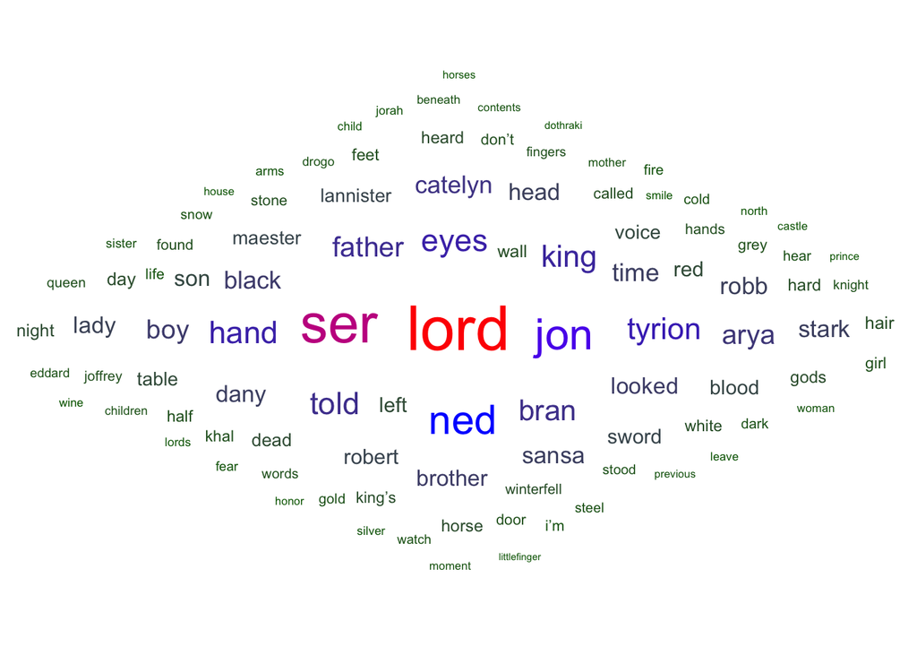

```r
ggplot(data = got_top100, aes(label = word, size = n)) +
  geom_text_wordcloud_area(aes(color = n), shape = "diamond") +
  scale_size_area(max_size = 12) +
  scale_color_gradientn(colors = c("darkgreen","blue","red")) +
  theme_minimal()
```

### Sentiment analysis

I will download the lexicon “afinn” to be able to rank the words from -5 (very negative) to +5 (very positive).

```r
get_sentiments(lexicon = "afinn") #get_sentiments() gets the lexicon without the columns not used in the particular lexicon
```

```
## # A tibble: 2,477 × 2
##    word       value
##    <chr>      <dbl>
##  1 abandon       -2
##  2 abandoned     -2
##  3 abandons      -2
##  4 abducted      -2
##  5 abduction     -2
##  6 abductions    -2
##  7 abhor         -3
##  8 abhorred      -3
##  9 abhorrent     -3
## 10 abhors        -3
## # … with 2,467 more rows
```

```r
# Getting the pretty positive words:
afinn_pos <- get_sentiments("afinn") %>%
  filter(value %in% c(3,4,5))

# Getting the pretty negative words:
afinn_neg <- get_sentiments("afinn") %>%
  filter(value %in% c(-5,-4,-3))
```

I will download the lexicon “bing” to be able to sort the words in “positive” or “negative” words (binary sorting the words):

```r
get_sentiments(lexicon = "bing")
```

```
## # A tibble: 6,786 × 2
##    word        sentiment
##    <chr>       <chr>
##  1 2-faces     negative
##  2 abnormal    negative
##  3 abolish     negative
##  4 abominable  negative
##  5 abominably  negative
##  6 abominate   negative
##  7 abomination negative
##  8 abort       negative
##  9 aborted     negative
## 10 aborts      negative
## # … with 6,776 more rows
```

I get the NRC lexicon to be able to sort the words into bins for 8 emotions (anger, anticipation, disgust, fear, joy, sadness, surprise, trust) and positive / negative.

**Citation for NRC lexicon**: Crowdsourcing a Word-Emotion Association Lexicon, Saif Mohammad and Peter Turney, Computational Intelligence, 29 (3), 436-465, 2013.

```r
get_sentiments(lexicon = "nrc")
```

```
## # A tibble: 13,872 × 2
##    word        sentiment
##    <chr>       <chr>
##  1 abacus      trust
##  2 abandon     fear
##  3 abandon     negative
##  4 abandon     sadness
##  5 abandoned   anger
##  6 abandoned   fear
##  7 abandoned   negative
##  8 abandoned   sadness
##  9 abandonment anger
## 10 abandonment fear
## # … with 13,862 more rows
```

### Sentiment analysis with afinn:

I bind the words in `got_stop` (the list of words without the stop words) to the `afinn` lexicon:

```r
got_afinn <- got_stop %>%
  inner_join(get_sentiments("afinn"))
```

I count the words in each category (from -5 (most negative) to 5 (most positive)) and plot them. I haven’t actually read or watched Game of Thrones, but I have heard, that a lot of warfare and conflict is going on, so therefore I expect that the words will generally be slightly more negative than positive.

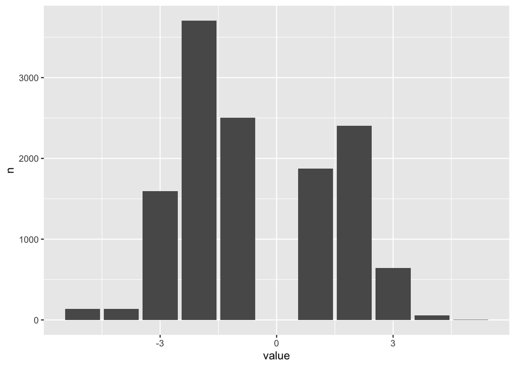

```r
got_afinn_hist <- got_afinn %>%
  count(value)

# Plot them:
ggplot(data = got_afinn_hist, aes(x = value, y = n)) +
  geom_col()
```

The most words are placed in the -2 category, which contains slightly negative words.

Now I will investigate the words in category -2 a bit more:

```r
# What are the words in category '-2'?
got_afinn_minus2 <- got_afinn %>%
  filter(value == -2)
```

```r
# Check the unique -2-score words:
unique(got_afinn_minus2$word)
```

```
##   [1] "fire"           "nervous"        "fear"           "haunted"
##   [5] "trouble"        "bored"          "distracted"     "interrupt"
##   [9] "fallen"         "enemy"          "steals"         "pain"
##  [13] "weak"           "sullen"         "weeping"        "careless"
##  [17] "wrong"          "afraid"         "warned"         "fool"
##  [21] "enemies"        "slashed"        "abandoned"      "failure"
##  [25] "trembling"      "death"          "screaming"      "clash"
##  [29] "cried"          "mocking"        "slash"          "shattered"
##  [33] "scream"         "ruin"           "sentence"       "struggling"
##  [37] "mistake"        "hurt"           "sad"            "troubled"
##  [41] "tears"          "bore"           "wasting"        "neglect"
##  [45] "gloomy"         "stubborn"       "brooding"       "melancholy"
##  [49] "deny"           "doom"           "poor"           "dread"
##  [53] "helpless"       "grief"          "lonely"         "frightened"
##  [57] "fail"           "steal"          "threatened"     "stolen"
```

[output cut: 82 more lines]

[figure not shown]

```r
# Count & plot them
got_afinn_minus2_n <- got_afinn_minus2 %>%
  count(word, sort = TRUE) %>%
  mutate(word = fct_reorder(factor(word), n))


ggplot(data = got_afinn_minus2_n, aes(x = word, y = n)) +
  geom_col() +
  coord_flip()
```

The plot is a bit hard to read, because there are so many words in the -2 category. Therefore I will check out how many times the individual -2 words occur and which words are most frequent.

```r
got_minus2_swc <- got_afinn_minus2 %>%
  count(word) %>%
  arrange(-n)

#checking the words out
got_minus2_swc
```

```
## # A tibble: 385 × 2
##    word       n
##    <chr>  <int>
##  1 fire     162
##  2 fear     156
##  3 death    114
##  4 afraid   102
##  5 pain      94
##  6 tears     81
##  7 hurt      72
##  8 fool      69
##  9 wrong     69
## 10 war       68
## # … with 375 more rows
```

“Fire”, “fear”, “death”, “afraid”, “pain”, “tears”, “hurt”, “fool”, “wrong” and “war” are the 10 most frequent words in category -2. It is worth noticing that fire isn’t necessary a negative word, because it can be quite positive to light up a fire in your fireplace or camp to keep warm or cook dinner. “Tears” can also be positive e.g. if you cry of happiness.

I will summarize sentiment for the report:

```r
got_summary <- got_afinn %>%
  summarize(
    mean_score = mean(value),
    median_score = median(value)
  )
```

Result: the mean (-0.542) and median (-1) scores indicate that the words are generally slightly negative in the Game of Thrones text.

### NRC lexicon for sentiment analysis

We can use the NRC lexicon to start “binning” the got text by the feelings they’re typically associated with. I will use inner_join() to combine the got text without the stop words with the nrc lexicon:

```r
got_nrc <- got_stop %>%
  inner_join(get_sentiments("nrc"))
```

Before counting the words I will check which words has now been excluded from the text

```r
got_exclude <- got_stop %>%
  anti_join(get_sentiments("nrc"))

# View(got_exclude)

# Count to find the most excluded:
got_exclude_n <- got_exclude %>%
  count(word, sort = TRUE)

head(got_exclude_n)
```

```
## # A tibble: 6 × 2
##   word       n
##   <chr>  <int>
## 1 ser     1023
## 2 jon      787
## 3 ned      743
## 4 tyrion   591
## 5 eyes     567
## 6 hand     567
```

The most excluded words are “ser”, some names (“Ned”, “Jon” and “Tyron”) and the words “eyes” and “hand” which are two quite neutral words I would say.

Now I count the words in the bins and plot them

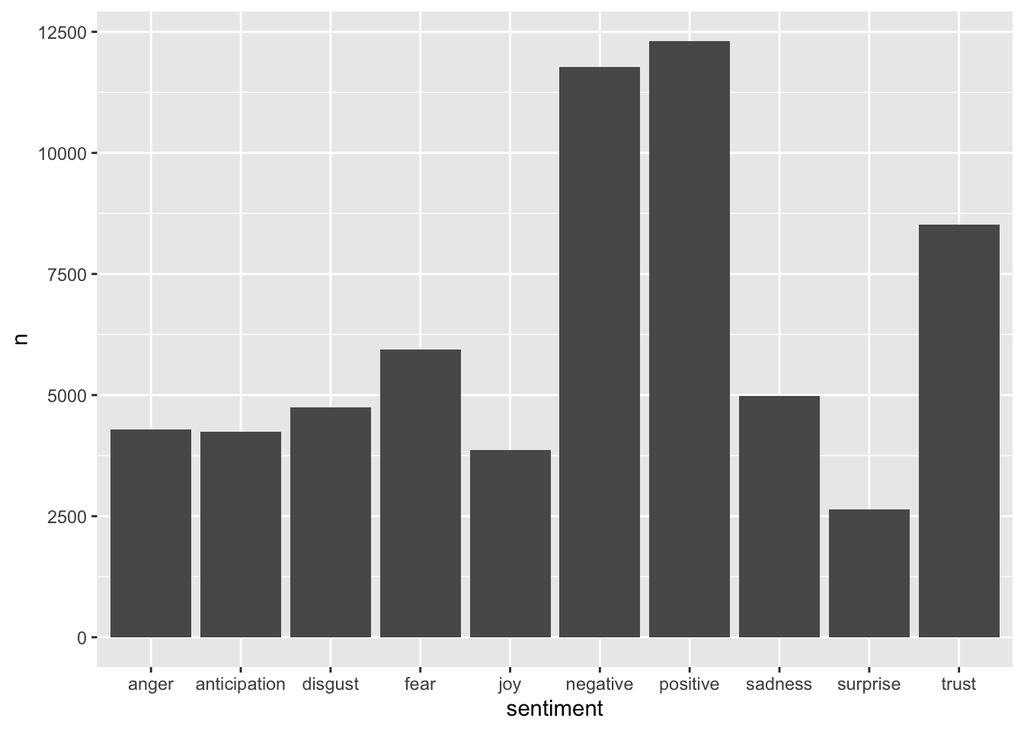

```r
got_nrc_n <- got_nrc %>%
  count(sentiment, sort = TRUE)

# And plot them:

ggplot(data = got_nrc_n, aes(x = sentiment, y = n)) +
  geom_col()
```

The analysis shows that the bin with the most words are the “positive” bin. But the “negative” bin is almost as big, and a lot of other bins with negative connotations such as “anger”, “disgust” and “fear” are also containing a lot of words.

I will count the words by sentiment *and* word, and then facet them:

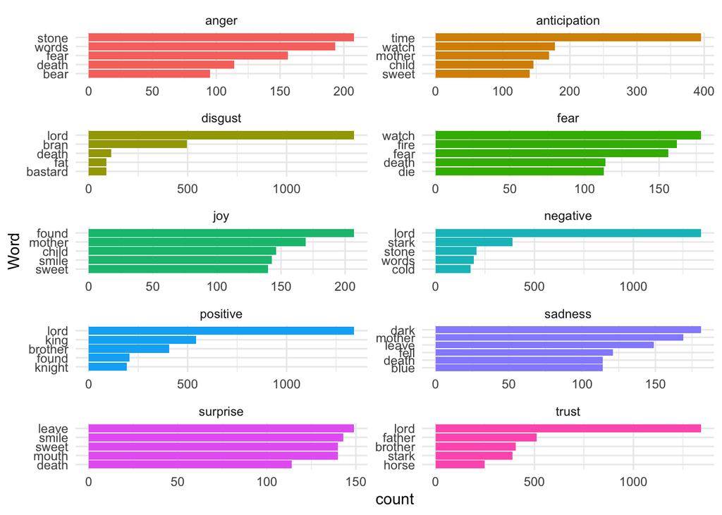

```r
got_nrc_n5 <- got_nrc %>%
  count(word,sentiment, sort = TRUE) %>%
  group_by(sentiment) %>%
  top_n(5) %>%
  ungroup()

got_nrc_gg <- ggplot(data = got_nrc_n5, aes(x = reorder(word,n), y = n, fill = sentiment)) +
  geom_col(show.legend = FALSE) +
  facet_wrap(~sentiment, ncol = 2, scales = "free") +
  coord_flip() +
  theme_minimal() +
  labs(x = "Word", y = "count")

# Show it
got_nrc_gg
```

```r
# Save it
ggsave(plot = got_nrc_gg,
       here("figures","got_nrc_sentiment.png"),
       height = 8,
       width = 5)
```

The word “lord” is ambugous, because it occures four of the bins, so the word is both binned as “disgust”, “negative”, “positive” and “trust”.

Checking if Lord is really in four bins

```r
lord <- get_sentiments(lexicon = "nrc") %>%
  filter(word == "lord")

# Check it out
lord # yep, lord is both in the disgust, negative, positive and trust bin
```

```
## # A tibble: 4 × 2
##   word  sentiment
##   <chr> <chr>
## 1 lord  disgust
## 2 lord  negative
## 3 lord  positive
## 4 lord  trust
```

Some things that surprises me from the chard:

Why is “stone” negative and not neutral? Why is “words” anger? It depends on the particular words. Why is “found” binned as joy? It must depend on what you find. Why is “blue” sad? Sometimes its just a colour without any symbolic meaning.